# act_report

## Report: act_report

Insights produced our wrangled data (master dataset) of tweet archive of Twitter user @dog_rates, also known as WeRateDogs. WeRateDogs is a Twitter account that rates people's dogs with a humorous comment about the dog.

### INSIGHTS

1. Average Dog rating (numerator) - We found the mean of all the ratings in the data set and our output given to be 10.61
2. Count of dog breed (top five) and thier averge rating - We used the group by function to compare the top five counts of dog breed with thier average rating. We found out that even though the Labrador_retriever had higher count, this breed had lower average rating compare to the Pembroke breed.
3. Average dog rating of top 10 retweet count VS Average dog rating of top 10 favorite count - We compare the top 10 retweet count to the top 10 favorite count and found out that Average dog rating of top 10 favorite count (12.9) was higher than the Average dog rating of top 10 retweet count (12.7)

### VISUALIZATION

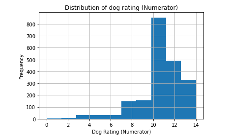